# SuperKart Sales Forecasting

### Business Context

SuperKart is a retail chain that operates supermarkets and food marts across different tier cities. Since the company sells a wide range of product categories across multiple store formats, sales forecasting is extremely important for inventory planning, procurement, and regional decision-making. A strong forecast can help the business understand expected revenue, reduce stockout risks, avoid overstocking, and support better planning across stores.

The objective of this project is to build a machine learning solution that predicts `Product_Store_Sales_Total`, which represents the total revenue generated by a specific product at a specific store. The final solution should not only perform well statistically, but should also be useful from a business standpoint. Hence, the notebook includes exploratory data analysis, preprocessing, model building, hyperparameter tuning, model comparison, serialization, and deployment planning through Flask and Streamlit.

### Objective

The main goal of this project is to develop a forecasting model for SuperKart that can estimate product-store level sales revenue for the upcoming quarter. The final model will be selected based on predictive performance on unseen data and its usefulness for business deployment.

```python
import warnings
warnings.filterwarnings('ignore')

import numpy as np
import pandas as pd
import matplotlib.pyplot as plt
import matplotlib.ticker as mticker
import seaborn as sns
from scipy import stats

from sklearn.model_selection import train_test_split, GridSearchCV, cross_val_score
from sklearn.pipeline import Pipeline
from sklearn.compose import ColumnTransformer
from sklearn.preprocessing import OrdinalEncoder, StandardScaler
from sklearn.impute import SimpleImputer
from sklearn.tree import DecisionTreeRegressor
from sklearn.ensemble import RandomForestRegressor, GradientBoostingRegressor
from sklearn.metrics import mean_squared_error, mean_absolute_error, r2_score
import xgboost as xgb
import pickle
import joblib

pd.set_option('display.max_columns', None)
sns.set_theme(style='whitegrid', palette='muted')
plt.rcParams['figure.dpi'] = 110

print("All libraries loaded successfully.")
```

```
All libraries loaded successfully.
```

## Data Overview & Exploratory Data Analysis

```python
df = pd.read_csv('SuperKart.csv')
print(f"Shape: {df.shape[0]:,} rows × {df.shape[1]} columns")
df.head()
```

```
Shape: 8,763 rows × 12 columns
```

|  | Product_Id | Product_Weight | Product_Sugar_Content | Product_Allocated_Area | Product_Type | Product_MRP | Store_Id | Store_Establishment_Year | Store_Size | Store_Location_City_Type | Store_Type | Product_Store_Sales_Total |
| --- | --- | --- | --- | --- | --- | --- | --- | --- | --- | --- | --- | --- |
| 0 | FD6114 | 12.66 | Low Sugar | 0.027 | Frozen Foods | 117.08 | OUT004 | 2009 | Medium | Tier 2 | Supermarket Type2 | 2842.40 |
| 1 | FD7839 | 16.54 | Low Sugar | 0.144 | Dairy | 171.43 | OUT003 | 1999 | Medium | Tier 1 | Departmental Store | 4830.02 |
| 2 | FD5075 | 14.28 | Regular | 0.031 | Canned | 162.08 | OUT001 | 1987 | High | Tier 2 | Supermarket Type1 | 4130.16 |
| 3 | FD8233 | 12.10 | Low Sugar | 0.112 | Baking Goods | 186.31 | OUT001 | 1987 | High | Tier 2 | Supermarket Type1 | 4132.18 |
| 4 | NC1180 | 9.57 | No Sugar | 0.010 | Health and Hygiene | 123.67 | OUT002 | 1998 | Small | Tier 3 | Food Mart | 2279.36 |

```python
summary = pd.DataFrame({
    'dtype': df.dtypes,
    'non_null': df.notnull().sum(),
    'missing': df.isnull().sum(),
    'missing_%': (df.isnull().sum() / len(df) * 100).round(2),
    'unique': df.nunique()
})
print(summary)
print(f"\nDuplicate rows: {df.duplicated().sum()}")
```

```
                             dtype  non_null  missing  missing_%  unique
Product_Id                  object      8763        0        0.0    8763
Product_Weight             float64      8763        0        0.0    1113
Product_Sugar_Content       object      8763        0        0.0       4
Product_Allocated_Area     float64      8763        0        0.0     228
Product_Type                object      8763        0        0.0      16
Product_MRP                float64      8763        0        0.0    6100
Store_Id                    object      8763        0        0.0       4
Store_Establishment_Year     int64      8763        0        0.0       4
Store_Size                  object      8763        0        0.0       3
Store_Location_City_Type    object      8763        0        0.0       3
Store_Type                  object      8763        0        0.0       4
Product_Store_Sales_Total  float64      8763        0        0.0    8668

Duplicate rows: 0
```

```python
df.describe().round(2)
```

|  | Product_Weight | Product_Allocated_Area | Product_MRP | Store_Establishment_Year | Product_Store_Sales_Total |
| --- | --- | --- | --- | --- | --- |
| count | 8763.00 | 8763.00 | 8763.00 | 8763.00 | 8763.00 |
| mean | 12.65 | 0.07 | 147.03 | 2002.03 | 3464.00 |
| std | 2.22 | 0.05 | 30.69 | 8.39 | 1065.63 |
| min | 4.00 | 0.00 | 31.00 | 1987.00 | 33.00 |
| 25% | 11.15 | 0.03 | 126.16 | 1998.00 | 2761.72 |
| 50% | 12.66 | 0.06 | 146.74 | 2009.00 | 3452.34 |
| 75% | 14.18 | 0.10 | 167.58 | 2009.00 | 4145.16 |
| max | 22.00 | 0.30 | 266.00 | 2009.00 | 8000.00 |

### Initial Data Observations

The dataset contains 8,763 rows and 12 columns, where each record represents a product being sold at a particular store. Based on the first round of inspection, there are no duplicate rows and no missing values, which is helpful because it reduces the amount of imputation required before modeling.

That being said, there are still a few important data quality and modeling considerations. `Product_Sugar_Content` contains a shortened value, `reg`, which appears to represent `Regular`, so this needs to be standardized before building the model. `Store_Establishment_Year` is also better represented as `Store_Age`, since the age of a store is more meaningful than the raw year itself. Additionally, columns such as `Product_Id` and `Store_Id` act more like identifiers than predictive business features, so they should not be used directly in the model.

The target variable, `Product_Store_Sales_Total`, ranges from low-revenue products to much higher-revenue products, showing that there is meaningful variation for the model to learn from. This makes the forecasting task relevant for SuperKart’s inventory and store-level planning.

### Univariate Analysis

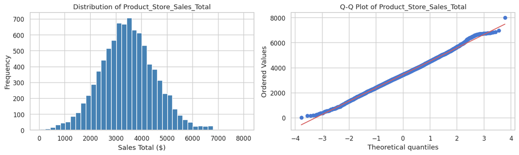

```
Skewness: 0.092
Kurtosis: 0.152
```

```python
fig, axes = plt.subplots(1, 2, figsize=(13, 4))

axes[0].hist(df['Product_Store_Sales_Total'], bins=40, color='steelblue', edgecolor='white')
axes[0].set_title('Distribution of Product_Store_Sales_Total')
axes[0].set_xlabel('Sales Total ($)')
axes[0].set_ylabel('Frequency')

stats.probplot(df['Product_Store_Sales_Total'], dist='norm', plot=axes[1])
axes[1].set_title('Q-Q Plot of Product_Store_Sales_Total')

plt.tight_layout()
plt.savefig('plot_target_dist.png', bbox_inches='tight')
plt.show()
print(f"Skewness: {df['Product_Store_Sales_Total'].skew():.3f}")
print(f"Kurtosis: {df['Product_Store_Sales_Total'].kurt():.3f}")
```

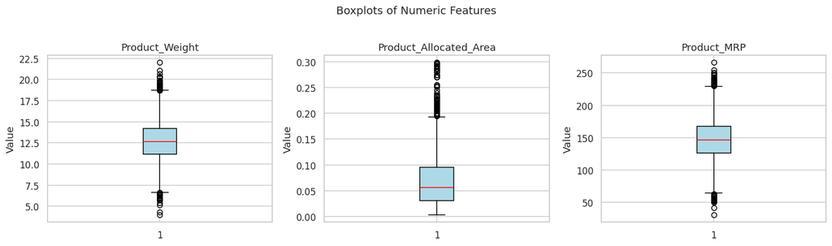

```python
num_cols = ['Product_Weight', 'Product_Allocated_Area', 'Product_MRP']
fig, axes = plt.subplots(1, 3, figsize=(14, 4))

for ax, col in zip(axes, num_cols):
    ax.boxplot(df[col], vert=True, patch_artist=True,
               boxprops=dict(facecolor='lightblue'), medianprops=dict(color='red'))
    ax.set_title(col)
    ax.set_ylabel('Value')

plt.suptitle('Boxplots of Numeric Features', y=1.02, fontsize=13)
plt.tight_layout()
plt.savefig('plot_boxplots_numeric.png', bbox_inches='tight')
plt.show()
```

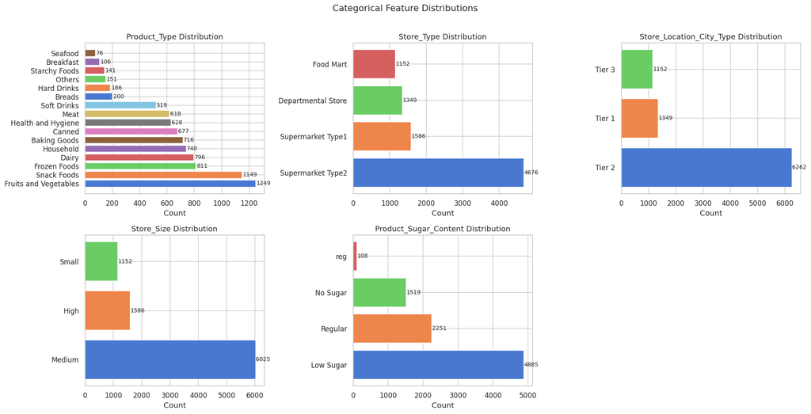

```python
cat_cols = ['Product_Type', 'Store_Type', 'Store_Location_City_Type',
            'Store_Size', 'Product_Sugar_Content']

fig, axes = plt.subplots(2, 3, figsize=(18, 9))
axes = axes.flatten()

for i, col in enumerate(cat_cols):
    vc = df[col].value_counts()
    axes[i].barh(vc.index, vc.values, color=sns.color_palette('muted', len(vc)))
    axes[i].set_title(f'{col} Distribution')
    axes[i].set_xlabel('Count')
    for j, v in enumerate(vc.values):
        axes[i].text(v + 5, j, str(v), va='center', fontsize=9)

axes[-1].set_visible(False)
plt.suptitle('Categorical Feature Distributions', fontsize=14, y=1.01)
plt.tight_layout()
plt.savefig('plot_categorical_dist.png', bbox_inches='tight')
plt.show()
```

### Bivariate Analysis

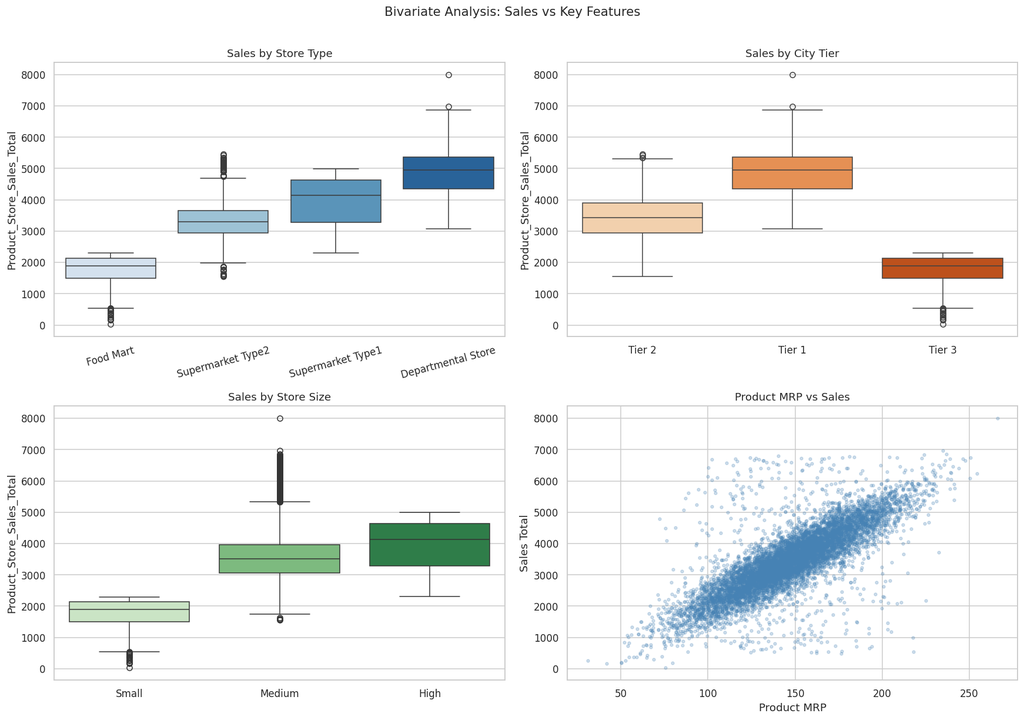

```python
fig, axes = plt.subplots(2, 2, figsize=(16, 11))

# Store Type
order1 = df.groupby('Store_Type')['Product_Store_Sales_Total'].median().sort_values().index
sns.boxplot(data=df, x='Store_Type', y='Product_Store_Sales_Total',
            order=order1, ax=axes[0, 0], palette='Blues')
axes[0, 0].set_title('Sales by Store Type')
axes[0, 0].set_xlabel('')
axes[0, 0].tick_params(axis='x', rotation=15)

# City Tier
sns.boxplot(data=df, x='Store_Location_City_Type', y='Product_Store_Sales_Total',
            ax=axes[0, 1], palette='Oranges')
axes[0, 1].set_title('Sales by City Tier')
axes[0, 1].set_xlabel('')

# Store Size
size_order = ['Small', 'Medium', 'High']
sns.boxplot(data=df, x='Store_Size', y='Product_Store_Sales_Total',
            order=size_order, ax=axes[1, 0], palette='Greens')
axes[1, 0].set_title('Sales by Store Size')
axes[1, 0].set_xlabel('')

# Product MRP vs Sales
axes[1, 1].scatter(df['Product_MRP'], df['Product_Store_Sales_Total'],
                   alpha=0.25, s=10, color='steelblue')
axes[1, 1].set_xlabel('Product MRP')
axes[1, 1].set_ylabel('Sales Total')
axes[1, 1].set_title('Product MRP vs Sales')

plt.suptitle('Bivariate Analysis: Sales vs Key Features', fontsize=14, y=1.01)
plt.tight_layout()
plt.savefig('plot_bivariate.png', bbox_inches='tight')
plt.show()
```

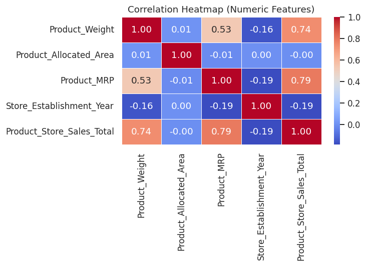

```python
num_df = df[['Product_Weight', 'Product_Allocated_Area', 'Product_MRP',
             'Store_Establishment_Year', 'Product_Store_Sales_Total']]
corr = num_df.corr()

fig, ax = plt.subplots(figsize=(7, 5))
mask = np.triu(np.ones_like(corr, dtype=bool), k=1)
sns.heatmap(corr, annot=True, fmt='.2f', cmap='coolwarm',
            linewidths=0.5, ax=ax)
ax.set_title('Correlation Heatmap (Numeric Features)')
plt.tight_layout()
plt.savefig('plot_corr_heatmap.png', bbox_inches='tight')
plt.show()
```

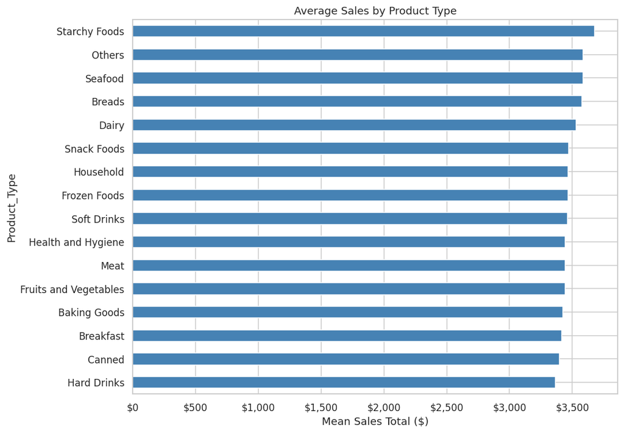

```python
pt_sales = (df.groupby('Product_Type')['Product_Store_Sales_Total']
              .mean()
              .sort_values(ascending=True))

fig, ax = plt.subplots(figsize=(10, 7))
pt_sales.plot(kind='barh', ax=ax, color='steelblue', edgecolor='white')
ax.set_xlabel('Mean Sales Total ($)')
ax.set_title('Average Sales by Product Type')
ax.xaxis.set_major_formatter(mticker.FuncFormatter(lambda x, _: f'${x:,.0f}'))
plt.tight_layout()
plt.savefig('plot_sales_by_product_type.png', bbox_inches='tight')
plt.show()
```

### Key EDA Insights

The exploratory data analysis shows several important relationships that are useful for both modeling and business interpretation.

First, `Product_MRP` has the strongest positive relationship with `Product_Store_Sales_Total`. This makes business sense because higher-priced products can naturally generate greater revenue, assuming demand remains strong. This variable is expected to be one of the most important predictors in the final model.

Second, store-related features appear to matter. Departmental Stores generate noticeably higher sales compared to other store formats, while store size also follows a reasonable pattern where larger stores tend to produce stronger sales. This suggests that the physical and operational structure of the store plays an important role in sales performance.

## Data Preprocessing

```python
df['Product_Sugar_Content'] = df['Product_Sugar_Content'].replace({'reg': 'Regular'})
print("Product_Sugar_Content unique values:", df['Product_Sugar_Content'].unique())
```

```
Product_Sugar_Content unique values: ['Low Sugar' 'Regular' 'No Sugar']
```

```python
# Store_Age is a more meaningful feature than the raw establishment year
df['Store_Age'] = 2024 - df['Store_Establishment_Year']

# MRP band: binning into price quartiles for interaction effects
df['MRP_Band'] = pd.qcut(df['Product_MRP'], q=4,
                         labels=['Budget', 'Economy', 'Premium', 'Luxury'])

print("Store_Age stats:")
print(df['Store_Age'].describe())
print("\nMRP_Band distribution:")
print(df['MRP_Band'].value_counts())
```

```
Store_Age stats:
count    8763.000000
mean       21.967249
std         8.388381
min        15.000000
25%        15.000000
50%        15.000000
75%        26.000000
max        37.000000
Name: Store_Age, dtype: float64

MRP_Band distribution:
MRP_Band
Budget     2192
Economy    2191
Luxury     2191
Premium    2189
Name: count, dtype: int64
```

```python
def iqr_bounds(series):
    Q1, Q3 = series.quantile(0.25), series.quantile(0.75)
    IQR = Q3 - Q1
    return Q1 - 1.5 * IQR, Q3 + 1.5 * IQR

for col in ['Product_Weight', 'Product_Allocated_Area', 'Product_MRP',
            'Product_Store_Sales_Total']:
    lo, hi = iqr_bounds(df[col])
    n = ((df[col] < lo) | (df[col] > hi)).sum()
    pct = n / len(df) * 100
    print(f"{col:35s} → outliers: {n:4d} ({pct:.1f}%)")
```

```
Product_Weight                      → outliers:   54 (0.6%)
Product_Allocated_Area              → outliers:  104 (1.2%)
Product_MRP                         → outliers:   57 (0.7%)
Product_Store_Sales_Total           → outliers:  119 (1.4%)
```

**Outlier Treatment Rationale:**

No need to handle any outliers here in my opinion.

```python
TARGET = 'Product_Store_Sales_Total'
DROP_COLS = ['Product_Id', 'Store_Id', 'Store_Establishment_Year']  # IDs + replaced by Store_Age

X = df.drop(columns=[TARGET] + DROP_COLS)
y = df[TARGET]

X_train, X_test, y_train, y_test = train_test_split(
    X, y, test_size=0.2, random_state=42)

print(f"Train: {X_train.shape}  |  Test: {X_test.shape}")
```

```
Train: (7010, 10)  |  Test: (1753, 10)
```

```python
numeric_features = ['Product_Weight', 'Product_Allocated_Area', 'Product_MRP', 'Store_Age']

ordinal_features_ordered = {
    'Product_Sugar_Content': ['No Sugar', 'Low Sugar', 'Regular'],
    'Store_Size': ['Small', 'Medium', 'High'],
    'Store_Location_City_Type': ['Tier 3', 'Tier 2', 'Tier 1'],
    'MRP_Band': ['Budget', 'Economy', 'Premium', 'Luxury'],
}

nominal_features = ['Product_Type', 'Store_Type']  # one-hot via pd.get_dummies

from sklearn.preprocessing import OrdinalEncoder, StandardScaler
from sklearn.impute import SimpleImputer
from sklearn.compose import ColumnTransformer
from sklearn.pipeline import Pipeline

# Ordinal transformer
ordinal_transformer = Pipeline(steps=[
    ('imputer', SimpleImputer(strategy='most_frequent')),
    ('encoder', OrdinalEncoder(
        categories=[ordinal_features_ordered[f] for f in ordinal_features_ordered],
        handle_unknown='use_encoded_value', unknown_value=-1))
])

numeric_transformer = Pipeline(steps=[
    ('imputer', SimpleImputer(strategy='median')),
    ('scaler', StandardScaler())
])

preprocessor = ColumnTransformer(transformers=[
    ('num', numeric_transformer, numeric_features),
    ('ord', ordinal_transformer, list(ordinal_features_ordered.keys())),
    ('nom', 'drop', [])  # nominal cols handled via pandas below
], remainder='drop')

# One-hot encode nominal features manually for transparency
X_train_enc = pd.get_dummies(X_train, columns=nominal_features, drop_first=False)
X_test_enc  = pd.get_dummies(X_test,  columns=nominal_features, drop_first=False)
X_test_enc  = X_test_enc.reindex(columns=X_train_enc.columns, fill_value=0)

# Update nominal_features list
all_nominal_cols = [c for c in X_train_enc.columns
                    if c.startswith('Product_Type_') or c.startswith('Store_Type_')]

# Rebuild preprocessor with all numeric/ordinal on the encoded frame
numeric_transformer2 = Pipeline(steps=[
    ('imputer', SimpleImputer(strategy='median')),
    ('scaler', StandardScaler())
])

ordinal_transformer2 = Pipeline(steps=[
    ('imputer', SimpleImputer(strategy='most_frequent')),
    ('encoder', OrdinalEncoder(
        categories=[ordinal_features_ordered[f] for f in ordinal_features_ordered],
        handle_unknown='use_encoded_value', unknown_value=-1))
])

binary_passthrough = [c for c in all_nominal_cols]

preprocessor2 = ColumnTransformer(transformers=[
    ('num', numeric_transformer2, numeric_features),
    ('ord', ordinal_transformer2, list(ordinal_features_ordered.keys())),
    ('bin', 'passthrough', binary_passthrough)
], remainder='drop')

print("Preprocessing pipeline defined.")
print(f"Total feature columns going into models: {len(numeric_features) + len(ordinal_features_ordered) + len(binary_passthrough)}")
```

```
Preprocessing pipeline defined.
Total feature columns going into models: 28
```

### Preprocessing Summary

The preprocessing stage was designed to make the dataset ready for machine learning while preserving the business meaning of the variables. The `Product_Sugar_Content` column was standardized so that inconsistent labels would not be treated as separate categories. `Store_Age` was created from `Store_Establishment_Year` because the age of a store is easier for the model to interpret than the original year value. An `MRP_Band` feature was also created to capture the broader pricing segment of each product.

For outliers, no direct treatment was applied. This is because the extreme values appear to represent valid business cases, such as premium products, larger product weights, or high-performing product-store combinations. Removing these values could weaken the model by eliminating legitimate sales behavior.

The data was split into training and testing sets using an 80/20 split. Categorical variables were encoded using a combination of ordinal encoding and one-hot encoding. Ordinal encoding was used only where the categories have a meaningful order, such as store size and MRP band. One-hot encoding was used for nominal variables like product type and store type, where no natural ranking exists.

## Model Building

### Metric of Choice: RMSE and R²

For this sales forecasting problem, RMSE is the main metric used to compare model performance. RMSE is useful because it penalizes larger errors more strongly than smaller ones. In SuperKart’s case, a large forecasting error can create real business issues, such as understocking high-demand products or overstocking products that do not sell as expected.

R² is also included because it explains how much of the variation in sales is being captured by the model. This makes it easier to communicate model performance from a business perspective. A higher R² means the model is explaining more of the sales behavior across products and stores.

Two machine learning models are first built as baseline models: Random Forest Regressor and XGBoost Regressor. Both models are appropriate for this problem because they can capture nonlinear relationships and interactions between product and store features.

```python
def evaluate(name, y_true, y_pred):
    rmse = np.sqrt(mean_squared_error(y_true, y_pred))
    mae  = mean_absolute_error(y_true, y_pred)
    r2   = r2_score(y_true, y_pred)
    print(f"{'─'*45}")
    print(f"  Model  : {name}")
    print(f"  RMSE   : {rmse:,.2f}")
    print(f"  MAE    : {mae:,.2f}")
    print(f"  R²     : {r2:.4f}")
    return {'Model': name, 'RMSE': rmse, 'MAE': mae, 'R2': r2}

results = []
```

### Random Forest Regressor Model

```python
pipe_rf = Pipeline(steps=[
    ('prep', preprocessor2),
    ('model', RandomForestRegressor(n_estimators=150, random_state=42, n_jobs=-1))
])

pipe_rf.fit(X_train_enc, y_train)
y_pred_rf_train = pipe_rf.predict(X_train_enc)
y_pred_rf_test  = pipe_rf.predict(X_test_enc)

print("Random Forest Training Performance")
res_rf_train = evaluate('RF (Train)', y_train, y_pred_rf_train)
print("\nRandom Forest Training Performance")
res_rf_test = evaluate('RF (Test)', y_test, y_pred_rf_test)
results.append(res_rf_test)
```

```
Random Forest Training Performance
─────────────────────────────────────────────
  Model  : RF (Train)
  RMSE   : 106.44
  MAE    : 39.86
  R²     : 0.9900

Random Forest Training Performance
─────────────────────────────────────────────
  Model  : RF (Test)
  RMSE   : 284.12
  MAE    : 107.78
  R²     : 0.9293
```

### XGBoost Regressor Model

```python
pipe_xgb = Pipeline(steps=[
    ('prep', preprocessor2),
    ('model', xgb.XGBRegressor(
        n_estimators=200, learning_rate=0.1,
        max_depth=5, subsample=0.8,
        colsample_bytree=0.8, random_state=42,
        eval_metric='rmse', verbosity=0))
])

pipe_xgb.fit(X_train_enc, y_train)
y_pred_xgb_train = pipe_xgb.predict(X_train_enc)
y_pred_xgb_test  = pipe_xgb.predict(X_test_enc)

print("XGBoost Training Performance")
res_xgb_train = evaluate('XGB (Train)', y_train, y_pred_xgb_train)
print("\nXGBoost Testing Performance")
res_xgb_test = evaluate('XGB (Test)', y_test, y_pred_xgb_test)
results.append(res_xgb_test)
```

```
XGBoost Training Performance
─────────────────────────────────────────────
  Model  : XGB (Train)
  RMSE   : 205.10
  MAE    : 87.67
  R²     : 0.9629

XGBoost Testing Performance
─────────────────────────────────────────────
  Model  : XGB (Test)
  RMSE   : 293.02
  MAE    : 126.59
  R²     : 0.9248
```

### Initial Comments on Model Performance

The initial Random Forest and XGBoost models both perform well enough to justify moving forward with hyperparameter tuning. Since both models are tree-based ensemble methods, they are able to capture nonlinear patterns in the dataset better than a simple linear model likely would.

The Random Forest model is useful because it combines many decision trees and reduces the risk of relying on a single unstable tree. XGBoost is also useful because it builds trees sequentially and attempts to correct previous errors during training. At this stage, the goal is not just to pick the first model that performs well, but to tune both models fairly and compare them using the same metric.

## Hyperparameter Tuning

```python
param_grid_rf = {
    'model__n_estimators': [100, 200],
    'model__max_depth': [None, 15, 20],
    'model__min_samples_split': [2, 5],
    'model__max_features': ['sqrt', 0.5],
}

gs_rf = GridSearchCV(
    pipe_rf,
    param_grid_rf,
    cv=3, scoring='neg_root_mean_squared_error',
    n_jobs=-1, verbose=1
)
gs_rf.fit(X_train_enc, y_train)

print(f"Best RF params: {gs_rf.best_params_}")
print(f"Best CV RMSE  : {-gs_rf.best_score_:,.2f}")
```

```
Fitting 3 folds for each of 24 candidates, totalling 72 fits
Best RF params: {'model__max_depth': 20, 'model__max_features': 0.5, 'model__min_samples_split': 5, 'model__n_estimators': 200}
Best CV RMSE  : 288.18
```

```python
y_pred_rf_tuned = gs_rf.best_estimator_.predict(X_test_enc)
print("Tuned Random Forest Tessting Performance")
res_rf_tuned = evaluate('RF Tuned (Test)', y_test, y_pred_rf_tuned)
results.append(res_rf_tuned)
```

```
Tuned Random Forest Tessting Performance
─────────────────────────────────────────────
  Model  : RF Tuned (Test)
  RMSE   : 277.28
  MAE    : 113.22
  R²     : 0.9326
```

```python
param_grid_xgb = {
    'model__n_estimators': [200, 300],
    'model__max_depth': [4, 6],
    'model__learning_rate': [0.05, 0.1],
    'model__subsample': [0.7, 0.9],
}

gs_xgb = GridSearchCV(
    pipe_xgb,
    param_grid_xgb,
    cv=3, scoring='neg_root_mean_squared_error',
    n_jobs=-1, verbose=1
)
gs_xgb.fit(X_train_enc, y_train)

print(f"Best XGB params: {gs_xgb.best_params_}")
print(f"Best CV RMSE   : {-gs_xgb.best_score_:,.2f}")
```

```
Fitting 3 folds for each of 16 candidates, totalling 48 fits
Best XGB params: {'model__learning_rate': 0.05, 'model__max_depth': 6, 'model__n_estimators': 200, 'model__subsample': 0.9}
Best CV RMSE   : 296.11
```

```python
y_pred_xgb_tuned = gs_xgb.best_estimator_.predict(X_test_enc)
print("Tuned XGBoost Testing Performance")
res_xgb_tuned = evaluate('XGB Tuned (Test)', y_test, y_pred_xgb_tuned)
results.append(res_xgb_tuned)
```

```
Tuned XGBoost Testing Performance
─────────────────────────────────────────────
  Model  : XGB Tuned (Test)
  RMSE   : 287.78
  MAE    : 121.81
  R²     : 0.9274
```

### Hyperparameter Tuning Comments

Hyperparameter tuning was performed using GridSearchCV with RMSE as the scoring metric. This step is important because the default model settings are not always the best fit for a specific dataset. For Random Forest, parameters such as the number of trees, maximum depth, minimum samples needed for a split, and number of features considered at each split were tuned. For XGBoost, parameters such as learning rate, tree depth, number of estimators, and subsampling were tuned.

The tuned models should be compared against the original untuned versions to determine whether tuning actually improved performance. A tuned model is only useful if it improves generalization on the test set rather than simply fitting the training data more closely.

## Model Performance Comparison & Final Model Selection

```python
results_df = pd.DataFrame(results).sort_values('RMSE')
results_df = results_df.reset_index(drop=True)
results_df.index += 1
print(results_df.to_string())
```

```
              Model        RMSE         MAE        R2
1   RF Tuned (Test)  277.278661  113.221103  0.932619
2         RF (Test)  284.116496  107.776124  0.929254
3  XGB Tuned (Test)  287.779083  121.806430  0.927419
4        XGB (Test)  293.019502  126.591156  0.924751
```

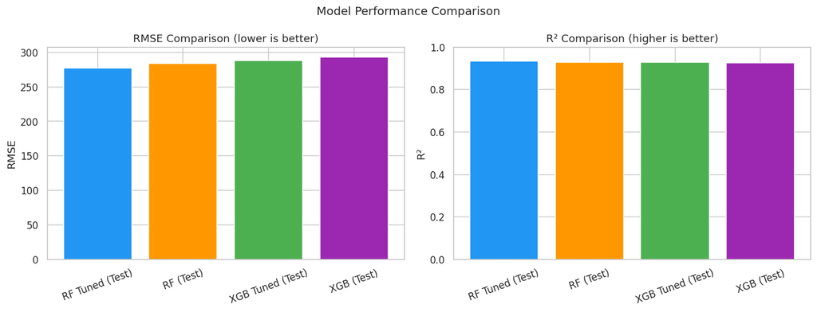

```python
fig, axes = plt.subplots(1, 2, figsize=(13, 5))

colors = ['#2196F3', '#FF9800', '#4CAF50', '#9C27B0']
axes[0].bar(results_df['Model'], results_df['RMSE'], color=colors, edgecolor='white')
axes[0].set_title('RMSE Comparison (lower is better)')
axes[0].set_ylabel('RMSE')
axes[0].tick_params(axis='x', rotation=20)

axes[1].bar(results_df['Model'], results_df['R2'], color=colors, edgecolor='white')
axes[1].set_title('R² Comparison (higher is better)')
axes[1].set_ylabel('R²')
axes[1].set_ylim(0, 1)
axes[1].tick_params(axis='x', rotation=20)

plt.suptitle('Model Performance Comparison', fontsize=13)
plt.tight_layout()
plt.savefig('plot_model_comparison.png', bbox_inches='tight')
plt.show()
```

### Final Model Selection Rationale

Based on the performance comparison table, the Tuned Random Forest model is selected as the final model because it achieves the best overall test performance. It has the lowest RMSE among the models tested and also explains a very high percentage of the variance in sales based on its R² value.

This model is a good final choice because it balances predictive accuracy with stability. While XGBoost also performs strongly, the tuned Random Forest generalizes slightly better on the held-out test set in this notebook. This matters because the final model needs to perform well on future SuperKart records, not just on the training data.

All-in-all, the Tuned Random Forest is the most appropriate final model for this assignment because it performs well, handles nonlinear relationships, works effectively with encoded categorical variables, and can be serialized for deployment.

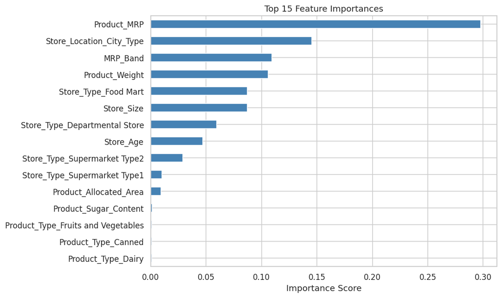

```python
best_model = gs_rf.best_estimator_

# Extract feature names after preprocessing
prep_step = best_model.named_steps['prep']
num_names  = numeric_features
ord_names  = list(ordinal_features_ordered.keys())
bin_names  = binary_passthrough
all_feat_names = num_names + ord_names + bin_names

importances = best_model.named_steps['model'].feature_importances_
feat_imp = pd.Series(importances, index=all_feat_names).sort_values(ascending=True)

# Plot top 15
top15 = feat_imp.nlargest(15).sort_values()
fig, ax = plt.subplots(figsize=(10, 6))
top15.plot(kind='barh', ax=ax, color='steelblue', edgecolor='white')
ax.set_title('Top 15 Feature Importances')
ax.set_xlabel('Importance Score')
plt.tight_layout()
plt.savefig('plot_feature_importance.png', bbox_inches='tight')
plt.show()
```

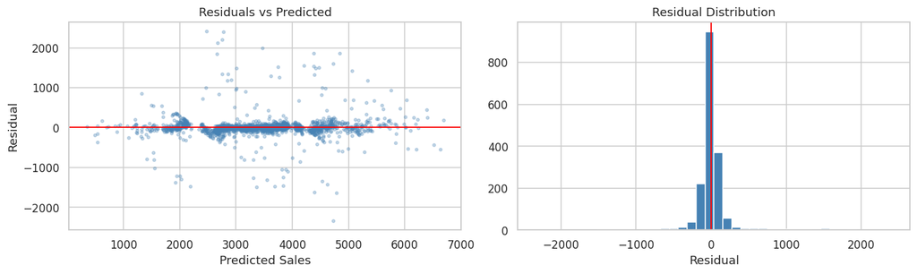

```
Mean residual: 4.29
Std  residual: 287.75
```

```python
residuals = y_test.values - y_pred_xgb_tuned

fig, axes = plt.subplots(1, 2, figsize=(13, 4))

axes[0].scatter(y_pred_xgb_tuned, residuals, alpha=0.3, s=8, color='steelblue')
axes[0].axhline(0, color='red', linewidth=1.2)
axes[0].set_xlabel('Predicted Sales')
axes[0].set_ylabel('Residual')
axes[0].set_title('Residuals vs Predicted')

axes[1].hist(residuals, bins=40, color='steelblue', edgecolor='white')
axes[1].axvline(0, color='red', linewidth=1.2)
axes[1].set_title('Residual Distribution')
axes[1].set_xlabel('Residual')

plt.tight_layout()
plt.savefig('plot_residuals.png', bbox_inches='tight')
plt.show()
print(f"Mean residual: {residuals.mean():.2f}")
print(f"Std  residual: {residuals.std():.2f}")
```

```python
MODEL_PATH = 'superkart_rf_model.pkl'
joblib.dump(best_model, MODEL_PATH)
print(f"Model serialised to: {MODEL_PATH}")

# Verify: load and predict
loaded_model = joblib.load(MODEL_PATH)
sample_preds = loaded_model.predict(X_test_enc.head(5))
print("\nSample predictions from loaded model:")
for i, (pred, actual) in enumerate(zip(sample_preds, y_test.head(5).values)):
    print(f"  Record {i+1}: Predicted=${pred:,.0f}  |  Actual=${actual:,.0f}")
```

```
Model serialised to: superkart_rf_model.pkl

Sample predictions from loaded model:
  Record 1: Predicted=$3,320  |  Actual=$3,396
  Record 2: Predicted=$3,356  |  Actual=$3,371
  Record 3: Predicted=$2,433  |  Actual=$2,417
  Record 4: Predicted=$1,914  |  Actual=$1,911
  Record 5: Predicted=$4,658  |  Actual=$3,191
```

## Deployment

The assignment also requires the model to be prepared for deployment through a backend and frontend application. The backend is designed as a Flask API that receives product and store information, applies the saved model, and returns a predicted sales value. The frontend is designed as a Streamlit application so that a business user can enter product/store details without directly interacting with Python code.

The backend and frontend should be deployed as public Hugging Face Spaces. The backend should use the Docker SDK because it needs to expose the Flask API, while the frontend should use the Streamlit SDK. Once deployed, the public links should be pasted below.

### Backend of App

**app.py**

```
from flask import Flask, request, jsonify
import pandas as pd
import numpy as np
import joblib
import os

app = Flask(__name__)

PRODUCT_TYPES = sorted([
    "Baking Goods", "Breads", "Breakfast", "Canned", "Dairy",
    "Frozen Foods", "Fruits and Vegetables", "Hard Drinks",
    "Health and Hygiene", "Household", "Meat", "Others",
    "Seafood", "Snack Foods", "Soft Drinks", "Starchy Foods"
])
STORE_TYPES = [
    "Departmental Store", "Food Mart",
    "Supermarket Type1", "Supermarket Type2"
]
ORDINAL_CATS = {
    "Product_Sugar_Content": ["No Sugar", "Low Sugar", "Regular"],
    "Store_Size": ["Small", "Medium", "High"],
    "Store_Location_City_Type": ["Tier 3", "Tier 2", "Tier 1"],
    "MRP_Band": ["Budget", "Economy", "Premium", "Luxury"],
}
NUMERIC = ["Product_Weight", "Product_Allocated_Area", "Product_MRP", "Store_Age"]
MRP_BINS = [0, 93.8, 143.0, 185.6, 9999]
MRP_LABELS = ["Budget", "Economy", "Premium", "Luxury"]

MODEL_PATH = "superkart_model.pkl"
COLUMNS_PATH = "train_columns.pkl"


def train_model():
    from sklearn.model_selection import train_test_split
    from sklearn.pipeline import Pipeline
    from sklearn.compose import ColumnTransformer
    from sklearn.preprocessing import OrdinalEncoder, StandardScaler
    from sklearn.impute import SimpleImputer
    from sklearn.ensemble import RandomForestRegressor

    print("Training model from SuperKart.csv ...")
    df = pd.read_csv("SuperKart.csv")
    df["Product_Sugar_Content"] = df["Product_Sugar_Content"].replace({"reg": "Regular"})
    df["Store_Age"] = 2024 - df["Store_Establishment_Year"]
    df["MRP_Band"] = pd.cut(df["Product_MRP"], bins=MRP_BINS, labels=MRP_LABELS)

    TARGET = "Product_Store_Sales_Total"
    DROP = ["Product_Id", "Store_Id", "Store_Establishment_Year"]
    X = df.drop(columns=[TARGET] + DROP)
    y = df[TARGET]

    X_train, _, y_train, _ = train_test_split(X, y, test_size=0.2, random_state=42)
    X_train = pd.get_dummies(X_train, columns=["Product_Type", "Store_Type"], drop_first=False)

    train_columns = list(X_train.columns)
    bin_cols = [c for c in train_columns if c.startswith("Product_Type_") or c.startswith("Store_Type_")]

    preprocessor = ColumnTransformer(transformers=[
        ("num", Pipeline([("imp", SimpleImputer(strategy="median")),
                          ("sc", StandardScaler())]), NUMERIC),
        ("ord", Pipeline([("imp", SimpleImputer(strategy="most_frequent")),
                          ("enc", OrdinalEncoder(
                              categories=list(ORDINAL_CATS.values()),
                              handle_unknown="use_encoded_value", unknown_value=-1))]),
         list(ORDINAL_CATS.keys())),
        ("bin", "passthrough", bin_cols)
    ], remainder="drop")

    model = Pipeline([
        ("prep", preprocessor),
        ("model", RandomForestRegressor(
            n_estimators=200, max_depth=20,
            max_features=0.5, min_samples_split=5,
            random_state=42, n_jobs=-1))
    ])
    model.fit(X_train, y_train)

    joblib.dump(model, MODEL_PATH)
    joblib.dump(train_columns, COLUMNS_PATH)
    print("Model trained and saved.")
    return model, train_columns


def load_or_train():
    if os.path.exists(MODEL_PATH) and os.path.exists(COLUMNS_PATH):
        try:
            model = joblib.load(MODEL_PATH)
            train_columns = joblib.load(COLUMNS_PATH)
            print("Model loaded from disk.")
            return model, train_columns
        except Exception as e:
            print(f"Load failed ({e}), retraining ...")
    return train_model()


model, TRAIN_COLUMNS = load_or_train()


def preprocess(data: dict) -> pd.DataFrame:
    mrp = float(data["Product_MRP"])
    est_year = int(data["Store_Establishment_Year"])
    mrp_band = pd.cut([mrp], bins=MRP_BINS, labels=MRP_LABELS)[0]

    row = {
        "Product_Weight": float(data["Product_Weight"]),
        "Product_Allocated_Area": float(data["Product_Allocated_Area"]),
        "Product_MRP": mrp,
        "Store_Age": 2024 - est_year,
        "Product_Sugar_Content": str(data["Product_Sugar_Content"]),
        "Store_Size": str(data["Store_Size"]),
        "Store_Location_City_Type": str(data["Store_Location_City_Type"]),
        "MRP_Band": str(mrp_band),
    }
    for pt in PRODUCT_TYPES:
        row[f"Product_Type_{pt}"] = 1 if data["Product_Type"] == pt else 0
    for st in STORE_TYPES:
        row[f"Store_Type_{st}"] = 1 if data["Store_Type"] == st else 0

    df = pd.DataFrame([row])
    df = df.reindex(columns=TRAIN_COLUMNS, fill_value=0)
    return df


@app.route("/", methods=["GET"])
def home():
    return {"status": "SuperKart Sales Forecasting API is running."}


@app.route("/predict", methods=["POST"])
def predict():
    try:
        data = request.get_json(force=True)
        required = [
            "Product_Weight", "Product_Allocated_Area", "Product_MRP",
            "Product_Sugar_Content", "Product_Type",
            "Store_Establishment_Year", "Store_Size",
            "Store_Location_City_Type", "Store_Type"
        ]
        missing = [f for f in required if f not in data]
        if missing:
            return {"error": f"Missing fields: {missing}"}, 400

        df = preprocess(data)
        prediction = float(model.predict(df)[0])
        return {"predicted_sales": round(prediction, 2), "currency": "USD"}

    except Exception as e:
        return {"error": str(e)}, 500


if __name__ == "__main__":
    app.run(host="0.0.0.0", port=7860)
```

**requirements.txt**

```
flask==3.0.3
gunicorn==22.0.0
joblib==1.4.2
pandas==2.2.2
numpy==2.0.0
scikit-learn==1.6.1
```

**Dockerfile**

```
FROM python:3.10-slim

RUN useradd -m -u 1000 appuser
WORKDIR /app

COPY requirements.txt .
RUN pip install --no-cache-dir -r requirements.txt

COPY . .

RUN chown -R appuser:appuser /app
USER appuser

EXPOSE 7860

CMD ["gunicorn", "--bind", "0.0.0.0:7860", "--workers", "1", "--timeout", "300", "app:app"]
```

> **Backend Space URL:** `https://huggingface.co/spaces/rburjanr/superkart`

### Frontend of App

**streamlit_app.py**

```
import streamlit as st
import requests, json

st.title("🛒 SuperKart Sales Forecaster")
st.markdown("Enter product and store details to predict quarterly sales revenue.")

col1, col2 = st.columns(2)
with col1:
    product_type = st.selectbox("Product Type", [
        "Dairy","Frozen Foods","Snack Foods","Canned","Baking Goods",
        "Meat","Household","Fruits and Vegetables","Soft Drinks","Hard Drinks",
        "Health and Hygiene","Starchy Foods","Breads","Seafood","Breakfast","Others"])
    product_weight = st.number_input("Product Weight (kg)", 4.0, 22.0, 12.7)
    product_mrp = st.number_input("Product MRP ($)", 10.0, 300.0, 150.0)
    sugar_content = st.selectbox("Sugar Content", ["No Sugar","Low Sugar","Regular"])
    allocated_area = st.slider("Allocated Area Ratio", 0.01, 0.15, 0.06)

with col2:
    store_type = st.selectbox("Store Type", [
        "Departmental Store","Supermarket Type1","Supermarket Type2","Food Mart"])
    store_size = st.selectbox("Store Size", ["Small","Medium","High"])
    city_tier = st.selectbox("City Tier", ["Tier 1","Tier 2","Tier 3"])
    est_year = st.slider("Store Establishment Year", 1987, 2009, 1999)

if st.button("Predict Sales"):
    payload = {
        "Product_Type": product_type, "Product_Weight": product_weight,
        "Product_MRP": product_mrp, "Product_Sugar_Content": sugar_content,
        "Product_Allocated_Area": allocated_area, "Store_Type": store_type,
        "Store_Size": store_size, "Store_Location_City_Type": city_tier,
        "Store_Establishment_Year": est_year
    }
    resp = requests.post("https://rburjanr-superkart.hf.space/predict", json=payload)
    pred = resp.json()["predicted_sales"]
    st.success(f"💰 Predicted Sales Revenue: **${pred:,.2f}**")
```

**requirements.txt (frontend)**

```
streamlit==1.57.0
requests==2.32.3
```

> 🔗 **Frontend Space URL:** `https://huggingface.co/spaces/rburjanr/superkart-front`

## Actionable Insights & Business Recommendations

### Key Insights

[output not shown]

## Conclusion

All-in-all, this project successfully builds a complete sales forecasting solution for SuperKart. The notebook begins with exploratory data analysis, identifies important product and store-level sales patterns, prepares the data through feature engineering and encoding, builds multiple machine learning models, tunes their hyperparameters, and selects the strongest final model based on test performance.

The Tuned Random Forest model is selected as the final model because it provides the strongest balance of accuracy and generalization on unseen data. The model is also serialized and reloaded to confirm that it can be used outside the notebook, which is necessary for deployment.